# Bioinformatics Resubmission

1900357

2023-08-05

```r
print("General RStudio Work")
```

```
## [1] "General RStudio Work"
```

#Below, the “sum()” function is used to add all of the whole numbers from 5 to 55 together. The output value is 1530.

```r
#Task 3.1
sum(5:55)
```

```
## [1] 1530
```

#Following this, the “sumfun()” function is created to calculate the sum between 5 and “n”, with n being 10, 20 or 100.

```r
#Task 3.2
sumfun <- function(n)

  {sum(5:n)}

sumfun(10)
```

```
## [1] 45
```

```r
sumfun(20)
```

```
## [1] 200
```

```r
sumfun(100)
```

```
## [1] 5040
```

#The fibonacci sequence is an integer sequence, with the first two terms as 0 and 1. The following terms are found by adding the previous two terms together. E.g. the next term after 0,1 is 1 (0 + 1 = 1), and so on and so forth. First, the fibonacci sequence must be created and calcuated. Here, we are setting parameters for “n” depending on the value of n, and what it the corresponding output should be. The vector function “c()” is also used to demonstrate the first two terms.

```r
#Task 3.3
print("Fibbonaci Series")
```

```
## [1] "Fibbonaci Series"
```

```r
fibonacci <- function(n) {
  if (n ==1) {
    return(0)
    } else if (n ==2) {
      return(1)
    } else {
      fib_seq <- c(0,1)
      for (i in 3:n) {
        next_num <- fib_seq[i-1] + fib_seq[i-2]
        fib_seq <- c(fib_seq, next_num)
      }
    return(fib_seq)
  }
}

#Here, the nth term is set as 12, as we require the first 12 terms of the fibonacci series.

n_entries <- 12
fib_series <- fibonacci(n_entries)

#The "print" function is used to visualise the first 12 terms of the fibonacci sequence.

print(fib_series)
```

```
##  [1]  0  1  1  2  3  5  8 13 21 34 55 89
```

#The mtcars dataset is a built-in dataset that can be used to help practise visualisation of different parameters, using packages such as “ggplot2”. This data will be used for the remaining tasks.

```r
print("mtcars dataset visualisation")
```

```
## [1] "mtcars dataset visualisation"
```

#First, we must retrieve the data.

```r
data(mtcars)
```

#The “head” function allows us to visualise the first few lines/ rows of data. This dataset provides information about 32 different cars, based on 11 factors such as miles per gallon (mpg), speed (vs), and the number of gears (gear).

```r
head(mtcars)
```

```
##                    mpg cyl disp  hp drat    wt  qsec vs am gear carb
## Mazda RX4         21.0   6  160 110 3.90 2.620 16.46  0  1    4    4
## Mazda RX4 Wag     21.0   6  160 110 3.90 2.875 17.02  0  1    4    4
## Datsun 710        22.8   4  108  93 3.85 2.320 18.61  1  1    4    1
## Hornet 4 Drive    21.4   6  258 110 3.08 3.215 19.44  1  0    3    1
## Hornet Sportabout 18.7   8  360 175 3.15 3.440 17.02  0  0    3    2
## Valiant           18.1   6  225 105 2.76 3.460 20.22  1  0    3    1
```

```r
installed.packages("ggplot2")
```

```
##      Package LibPath Version Priority Depends Imports LinkingTo Suggests
##      Enhances License License_is_FOSS License_restricts_use OS_type Archs
##      MD5sum NeedsCompilation Built
```

```r
library(ggplot2)
```

```r
names(mtcars)
```

```
##  [1] "mpg"  "cyl"  "disp" "hp"   "drat" "wt"   "qsec" "vs"   "am"   "gear"
## [11] "carb"
```

#The “ggpplot” function is used to show the mpg as a function of the number of gears, in the boxplot graph. The colour function is used, as well as labels for clarity.

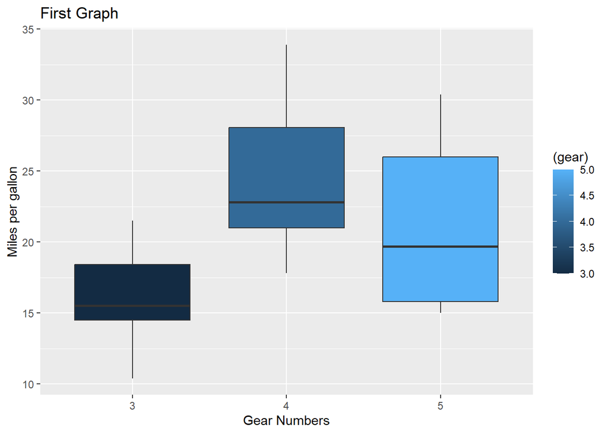

```r
#Task 3.4
ggplot(mtcars, aes(x= as.factor(gear),y=mpg))+
  geom_boxplot(aes(fill= (gear)))+
  labs(title="First Graph", x="Gear Numbers", y="Miles per gallon")
```

#In the next task, we want to find the relationship between spped and breaking distance, in the variable distance. First, we must set the variables as ‘x’ and ‘y’.

#After we have set the variables, the function (z) below is used to create a linear regression model (lm) on the above data. A linear regression model identifies a relationship between the two variables by creating a straight line betwen the two datas.

#The output summary provides a variety of information about the two variables, including the p-values. The p-values (right column under coefficients and last line) will determine whether the linear regression model is statistically significant. This is also denoted by the number of * by the value. The more ’*’, the more statistically significant the variable. In this case, both variables have p-values < 0.05, with high statistical significance, and so the linear regression is also significant.

```r
#Task 3.5
x <- cars$dist
y <- cars$speed

z <- lm(formula = "x ~ y", data = cars)

summary(z)
```

```
##
## Call:
## lm(formula = "x ~ y", data = cars)
##
## Residuals:
##     Min      1Q  Median      3Q     Max
## -29.069  -9.525  -2.272   9.215  43.201
##
## Coefficients:
##             Estimate Std. Error t value Pr(>|t|)
## (Intercept) -17.5791     6.7584  -2.601   0.0123 *
## y             3.9324     0.4155   9.464 1.49e-12 ***
## ---
## Signif. codes:  0 '***' 0.001 '**' 0.01 '*' 0.05 '.' 0.1 ' ' 1
##
## Residual standard error: 15.38 on 48 degrees of freedom
## Multiple R-squared:  0.6511, Adjusted R-squared:  0.6438
## F-statistic: 89.57 on 1 and 48 DF,  p-value: 1.49e-12
```

#In this task, we are using the “ggplot” function to create a plot of speed vs distance, as well as the “linear regression model” function to create a line across the data sets.

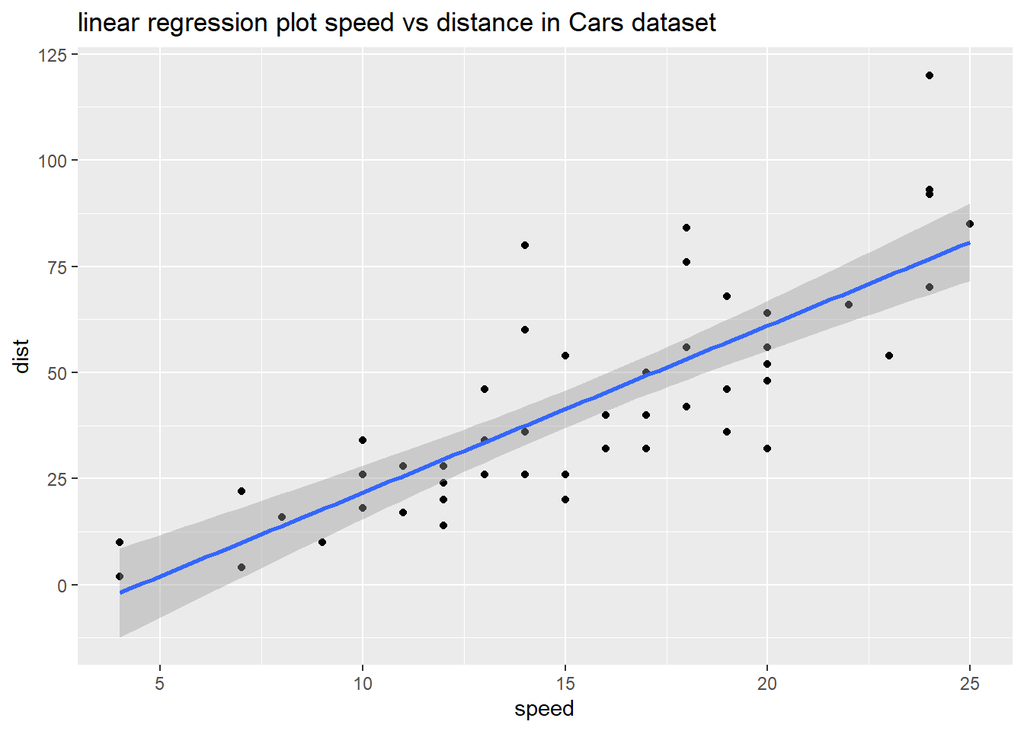

```r
#Task 3.6
input <- cars[,c('speed' , 'dist')]
#load the ggplot2 library
library(ggplot2)
c <- ggplot(data = cars, aes(x= speed, y=dist)) + geom_point() + geom_smooth(method = 'lm' ,formula = "y ~ x")
#To produce the title for the plot
c+ggtitle("linear regression plot speed vs distance in Cars dataset")
```

#In this last task, we are aiming to estimate the average reaction time for the braking distance. The “braking distance” is calculated as the distance that is travelled from the point of using the brake by the driver of the vehicle to the vehicle coming to a full stop. #The original data for the distance is in feet (ft), as such we multiply the data by 0.000189 to have the data in miles (mi). A new ggplot will also be created.

```r
#Task 3.7
#distance_miles = the variable for distance. The distance is converted from ft to miles by multiplying by 0.000189
distance_miles <- cars$dist*0.000189
#In this case, when the braking starts, it is assumed to be proportional to the square of the speed, denoted by the ^2.
speed_miles <- cars$speed^2
#The "lm" function demonstrates the model between the distance and the speed.
lm <- lm(formula = "distance_miles ~ speed_miles", data = cars)
summary(lm)
```

```
##
## Call:
## lm(formula = "distance_miles ~ speed_miles", data = cars)
##
## Residuals:
##        Min         1Q     Median         3Q        Max
## -0.0053766 -0.0017408 -0.0006793  0.0009594  0.0086679
##
## Coefficients:
##              Estimate Std. Error t value Pr(>|t|)
## (Intercept) 1.675e-03  7.723e-04   2.168   0.0351 *
## speed_miles 2.437e-05  2.492e-06   9.781  5.2e-13 ***
## ---
## Signif. codes:  0 '***' 0.001 '**' 0.01 '*' 0.05 '.' 0.1 ' ' 1
##
## Residual standard error: 0.002844 on 48 degrees of freedom
## Multiple R-squared:  0.6659, Adjusted R-squared:  0.6589
## F-statistic: 95.67 on 1 and 48 DF,  p-value: 5.2e-13
```

```r
lm$coefficients
```

```
##  (Intercept)  speed_miles
## 1.674549e-03 2.437508e-05
```

```r
#The reaction time is required in seconds, so 1 hr equates to 3,600 seconds.
reaction_time <- 2.437508e-05*3600
reaction_time
```

```
## [1] 0.08775029
```

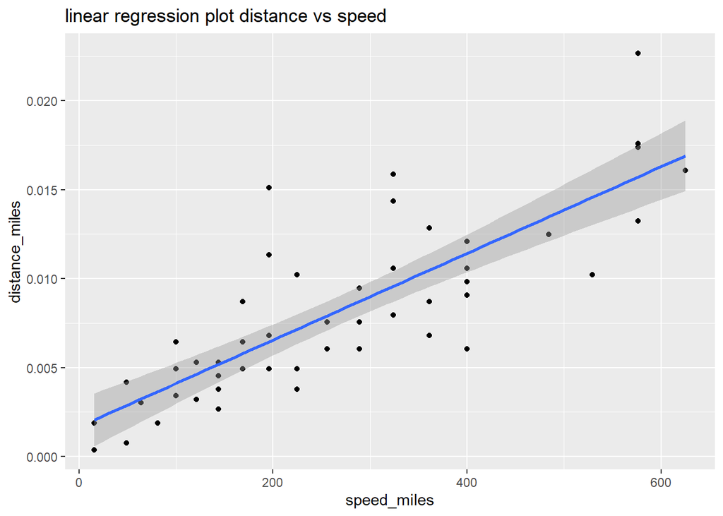

```r
#load the ggplot2 library
library(ggplot2)
#The variable 'a' is assigned to create a ggplot using the mtcars dataset. The x-axis is denoted as 'speed_miles', and the y-axis is denoted as 'distance_miles'. A linear regression model is also used.
a <- ggplot(data = cars, aes(x = speed_miles, y = distance_miles)) + geom_point() + geom_smooth(method = "lm",formula = "y ~ x")
#To produce the title for the plot to ensure clarity
plot <- a+ggtitle("linear regression plot distance vs speed")
plot
```